# Lab2_Report

## **ANS6905_Lab2 Checking Model Assumptions & Transfromation**

```r
library(tidyverse)
Glucose_data <- Glucose_data_raw %>% dplyr::select(BHBA_7_DIM,Glucose_7_DIM)
colnames(Glucose_data)
```

```
## [1] "BHBA_7_DIM"    "Glucose_7_DIM"
```

```r
NOrow = dim(Glucose_data)[1]
```

### **1.Regression Analysis: Checking Assumptions**

**1. Linear relationship: y ~ x**  
**2. Errors: Zero mean**  
**3. Errors: Constant variance σ2**  
**4. Errors: uncorrelated**  
**5. Errors: normality ε ~ Ν(0,σ2)**  
Estimations and inferences FULLY based on these assumptions.And they need to be **CHECKED**  
1. Graphical  
2. Numerical

```r
# First we fit a linear model
lmod_glu <- lm(BHBA_7_DIM ~ Glucose_7_DIM,
                 data = Glucose_data)
summary(lmod_glu)
```

```
##
## Call:
## lm(formula = BHBA_7_DIM ~ Glucose_7_DIM, data = Glucose_data)
##
## Residuals:
##     Min      1Q  Median      3Q     Max
## -0.7078 -0.3412 -0.1322  0.0389  4.0156
##
## Coefficients:
##               Estimate Std. Error t value Pr(>|t|)
## (Intercept)    4.22016    0.63779   6.617 2.48e-09 ***
## Glucose_7_DIM -0.05806    0.01061  -5.473 3.87e-07 ***
## ---
## Signif. codes:  0 '***' 0.001 '**' 0.01 '*' 0.05 '.' 0.1 ' ' 1
##
## Residual standard error: 0.7434 on 91 degrees of freedom
## Multiple R-squared:  0.2477, Adjusted R-squared:  0.2394
## F-statistic: 29.96 on 1 and 91 DF,  p-value: 3.873e-07
```

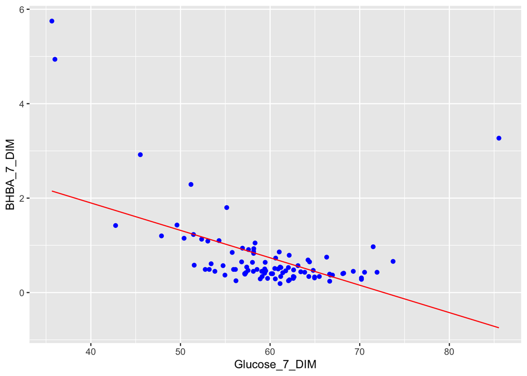

```r
plot_simple_lm = ggplot(data = Glucose_data,aes(x = Glucose_7_DIM , y = BHBA_7_DIM)) + geom_point(color='blue')
Glucose_data_pred <- add_column(Glucose_data, my_prediction = predict(lmod_glu))
plot_simple_lm + geom_line(color='red',data = Glucose_data_pred ,aes(x = Glucose_7_DIM , y= my_prediction))
```

Any departures from the assumptions on the model errors should appear in the residuals.

1.The most important diagnostic plot: ε_hat against y_hat,  
because we can check  
**zero mean** & **constant variance** & **relationship y~x**

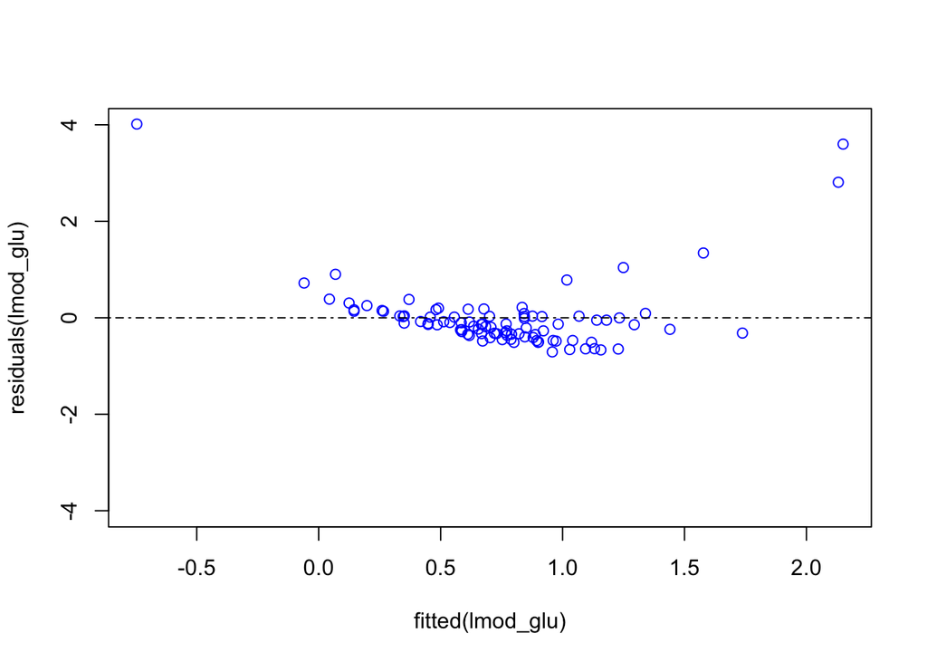

```r
plot(fitted(lmod_glu),residuals(lmod_glu),col = "blue",ylim = c(-max(abs(residuals(lmod_glu))),max(abs(residuals(lmod_glu)))));abline(h = 0,lty = 4)
```

2. Normal probability plot (Q-Q plot)  
   **if the residuals are normally distributed, then the points should form a straight line**

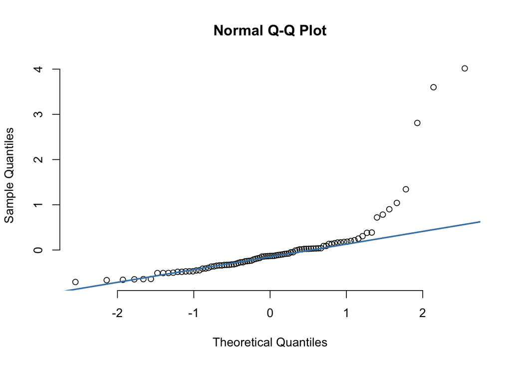

```r
qqnorm(residuals(lmod_glu), pch = 1, frame = FALSE);qqline(residuals(lmod_glu), col = "steelblue", lwd = 2)
```

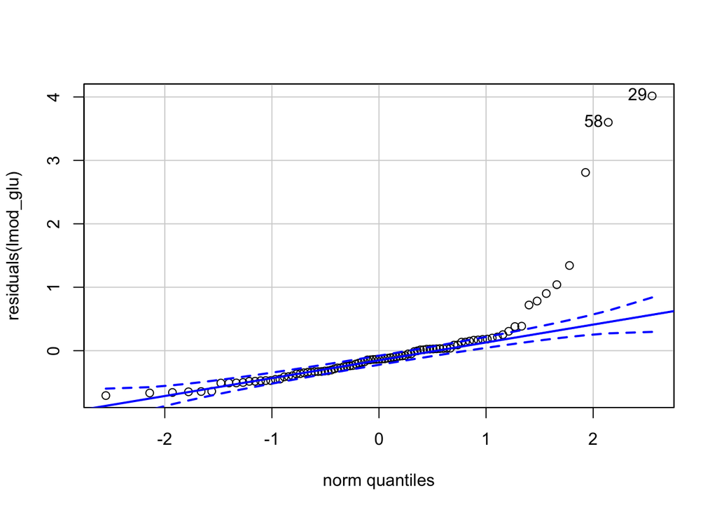

```
## [1] 29 58
```

```r
## with confidence band
library(car)
qqPlot(residuals(lmod_glu))
```

```r
library(ggpubr,quietly = T)
```

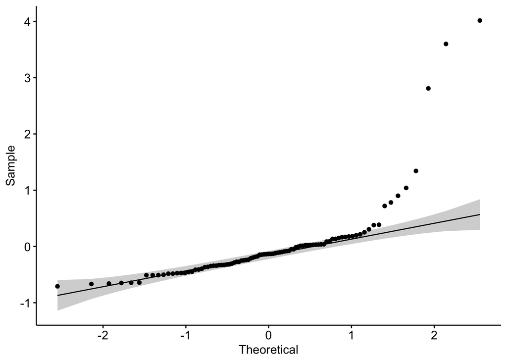

```r
ggqqplot(residuals(lmod_glu))
```

3. Checking normality using formal statistical tests.  
   H0: Data is normally distributed  
   H1: Data is not normally distributed

```r
# Shapiro–Wilk test
shapiro.test(residuals(lmod_glu))
```

```
##
##  Shapiro-Wilk normality test
##
## data:  residuals(lmod_glu)
## W = 0.60004, p-value = 1.555e-14
```

```r
# Kolmogorov–Smirnov test
ks.test(residuals(lmod_glu), "pnorm")
```

```
##
##  One-sample Kolmogorov-Smirnov test
##
## data:  residuals(lmod_glu)
## D = 0.28552, p-value = 3.334e-07
## alternative hypothesis: two-sided
```

```r
### Notes
# small samples most often pass normality tests (accept H0)
# large samples generally reject H0
```

4. Types of residuals  
   **1. Raw Residuals**  
   **2. Standarized Residuals**  
   **3. (internally) Studentized Residuals**  
   **4. (externally) Studentized Residuals / Jackknife residuals**

```r
library(MASS,quietly = T)
#### Raw Residuals
# get from the lm()
raw_res = residuals(lmod_glu)
# by hand
raw_res = Glucose_data$BHBA_7_DIM - predict(lmod_glu)
# of course they are the same
all.equal(raw_res,(Glucose_data$BHBA_7_DIM - predict(lmod_glu)))
```

```
## [1] TRUE
```

```r
#### Standarized Residuals
# by hand
y_hat = predict(lmod_glu)
SS_res = sum((Glucose_data$BHBA_7_DIM - y_hat)^2)
MSE = SS_res/(NOrow - 2)# an unbiased estimator of σ2
stan_res = residuals(lmod_glu)/sqrt(MSE)
# Seems not identical, the thres is near 1.5e-8, very strengent, also function has more massages...
# recommend use stdres() funcion,
all.equal(stdres(lmod_glu),stan_res)
```

```
## [1] "Mean relative difference: 0.0277333"
```

```r
stan_res = stdres(lmod_glu)
```

Before we jump to studentized residuals, we have to put together some pieces of code  
Then we have our **self-contained** functions to achieve any calculations.  
Sure, feel free to take this piece to get studentized residuals in your dataset,

```r
ModGet_CustomizeStudentRes = function(lmod){
  Studres_int = numeric(length(lmod$residuals))
  Studres_ext = numeric(length(lmod$residuals))
  Customized_MSE = numeric(length(lmod$residuals))
  message("Trying to remove each obs once at a time for a Customized MSE!")
  message("Preparing Hat matrix...")
  X <- model.matrix(lmod)
  H <- X %*% solve(t(X) %*% X) %*% t(X);message("Hat matrix done!")
  H_diag = diag(H)
  for (i in seq_along(lmod$residuals)){
    obverve_val = as.vector(predict(lmod)+residuals(lmod))[-i]
    y_hat = predict(lmod)[-i]
    SS_res = sum((obverve_val - y_hat)^2)
    Customized_MSE[i] = SS_res/((length(y_hat)) - length(lmod$coefficients))
    Studres_int[i] = lmod$residuals[i]/(summary(lmod)$sigma *sqrt(1 - H_diag[i]))
    Studres_ext[i] = lmod$residuals[i]/(sqrt(Customized_MSE[i])*sqrt(1 - H_diag[i]))
  }
  message("Custumization 1 done: ",length(Studres_int)," Internal studentized residuals were generated!");message("Custumization 2 done: ",length(Studres_int)," External studentized residuals were generated!")
  Results = list(StudentRes_internal = Studres_int, StudentRes_external= Studres_ext)
  return(Results)
}
# studres(lmod) # Jackknife
# rstudent(lmod) #Jackknife
```

```r
#### (Internally/External) Studentized Residuals
StuRes = ModGet_CustomizeStudentRes(lmod_glu)
```

```
## Trying to remove each obs once at a time for a Customized MSE!
```

```
## Preparing Hat matrix...
```

```
## Hat matrix done!
```

```
## Custumization 1 done: 93 Internal studentized residuals were generated!
```

```
## Custumization 2 done: 93 External studentized residuals were generated!
```

```r
Internal_StuRes = StuRes$StudentRes_internal
External_StuRes = StuRes$StudentRes_external
```

**Outlier**: Data point with a large residual  
**High Leverage**: Data point with a large hat value  
**Influential**:It has an unusual X-value with an unusual Y-value given its X-value

```r
# Outlier: large residuals (external studentized residuals)
#Bonferroni critical value - t_critic1
t_critic1 = qt(0.05/(2*NOrow),(NOrow -length(lmod_glu$coefficients)-1))
# find the outliers
rstudent(lmod_glu)[which((abs(rstudent(lmod_glu)) - abs(t_critic1))>= 0)]
```

```
##       29       58       92
## 7.360473 6.144957 4.434996
```

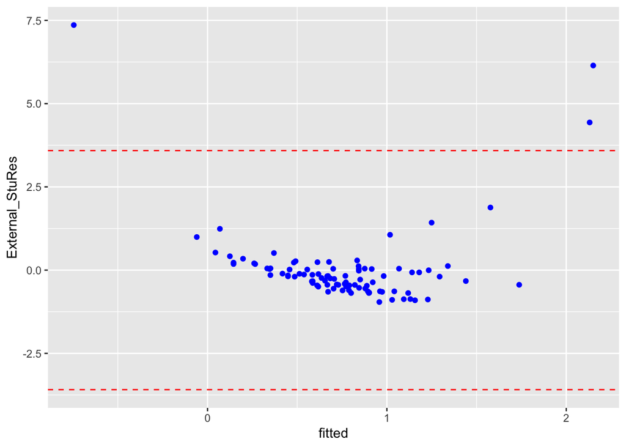

```r
# let's get grapical!
data.frame(fitted = lmod_glu$fitted.values,
           External_StuRes = rstudent(lmod_glu)) %>%
  ggplot(aes(x = fitted,y = External_StuRes))+
  geom_point(color='blue')+
  geom_hline(yintercept=t_critic1,color='red',linetype="dashed",size=.5)+
  geom_hline(yintercept=-t_critic1,color='red',linetype="dashed",size=.5)
```

```r
# high leverage: data point with a large hat_value
# set thres and select
h_critic1 = (2*length(lmod_glu$coefficients))/NOrow
all_hat = hatvalues(lmod_glu)
all_hat[which(all_hat - h_critic1 >= 0)]
```

```
##          3         29         48         57         58         92
## 0.06905640 0.14677958 0.05158882 0.05087390 0.12834224 0.12503854
```

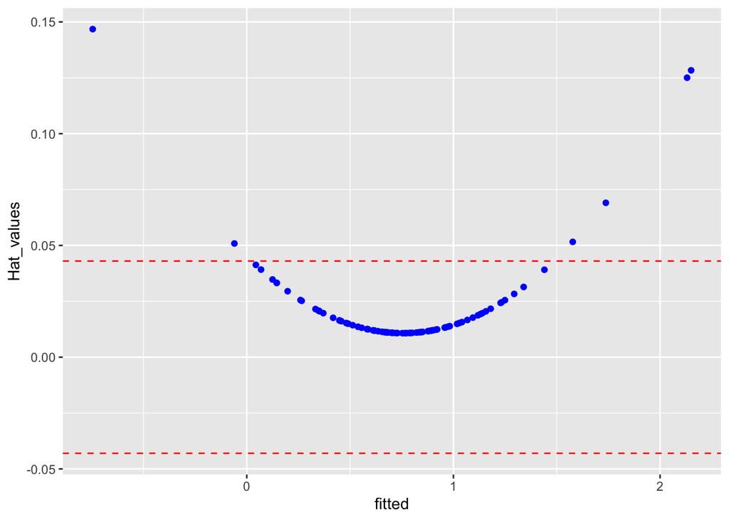

```r
# graphical
data.frame(fitted = lmod_glu$fitted.values,
           Hat_values = hatvalues(lmod_glu)) %>%
  ggplot(aes(x = fitted,y = Hat_values))+
  geom_point(color='blue')+
  geom_hline(yintercept=h_critic1,color='red',linetype="dashed",size=.5)+
  geom_hline(yintercept=-h_critic1,color='red',linetype="dashed",size=.5)
```

```r
# Influential: data point that greatly affects the estimates of the model
# Cook's Distance
library(car)
all_cook = cooks.distance(lmod_glu)
# set thres
ck_critic1 = 4/(NOrow -length(lmod_glu$coefficients))
ck_index = which((all_cook-ck_critic1)>=0);attr(ck_index,"names")=NULL
all_cook[ck_index]
```

```
##         29         48         58         92
## 2.94125460 0.09353953 1.98005000 1.16618689
```

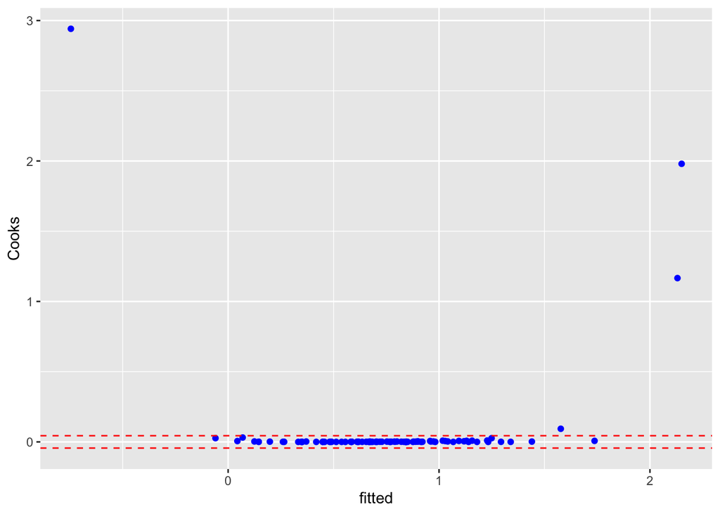

```r
# plots
data.frame(fitted = lmod_glu$fitted.values,
           Cooks = all_cook) %>%
  ggplot(aes(x = fitted,y = Cooks))+
  geom_point(color='blue')+
  geom_hline(yintercept=ck_critic1 ,color='red',linetype="dashed",size=.5)+
  geom_hline(yintercept=-ck_critic1 ,color='red',linetype="dashed",size=.5)
```

```r
# Now try to remove influential points that have considerable influence on the model
# Try to fit a new model ( %>% is the pipe operator, can pass objects down, ohhh thanks tidyverse)
lmod_glu_rm_ck <- Glucose_data %>%
  mutate(External_StuRes = rstudent(lmod_glu),
         All_hatvalues = all_hat,
         All_cooks_distance = all_cook) %>%
  filter(All_cooks_distance<ck_critic1) %>%
  lm(BHBA_7_DIM ~ Glucose_7_DIM,data =.)
summary(lmod_glu_rm_ck)
```

```
##
## Call:
## lm(formula = BHBA_7_DIM ~ Glucose_7_DIM, data = .)
##
## Residuals:
##      Min       1Q   Median       3Q      Max
## -0.47706 -0.21218 -0.05009  0.19203  1.39840
##
## Coefficients:
##                Estimate Std. Error t value Pr(>|t|)
## (Intercept)    2.568759   0.342923   7.491  5.3e-11 ***
## Glucose_7_DIM -0.032776   0.005682  -5.769  1.2e-07 ***
## ---
## Signif. codes:  0 '***' 0.001 '**' 0.01 '*' 0.05 '.' 0.1 ' ' 1
##
## Residual standard error: 0.3054 on 87 degrees of freedom
## Multiple R-squared:  0.2767, Adjusted R-squared:  0.2684
## F-statistic: 33.28 on 1 and 87 DF,  p-value: 1.199e-07
```

```r
summary(lmod_glu)
```

```
##
## Call:
## lm(formula = BHBA_7_DIM ~ Glucose_7_DIM, data = Glucose_data)
##
## Residuals:
##     Min      1Q  Median      3Q     Max
## -0.7078 -0.3412 -0.1322  0.0389  4.0156
##
## Coefficients:
##               Estimate Std. Error t value Pr(>|t|)
## (Intercept)    4.22016    0.63779   6.617 2.48e-09 ***
## Glucose_7_DIM -0.05806    0.01061  -5.473 3.87e-07 ***
## ---
## Signif. codes:  0 '***' 0.001 '**' 0.01 '*' 0.05 '.' 0.1 ' ' 1
##
## Residual standard error: 0.7434 on 91 degrees of freedom
## Multiple R-squared:  0.2477, Adjusted R-squared:  0.2394
## F-statistic: 29.96 on 1 and 91 DF,  p-value: 3.873e-07
```

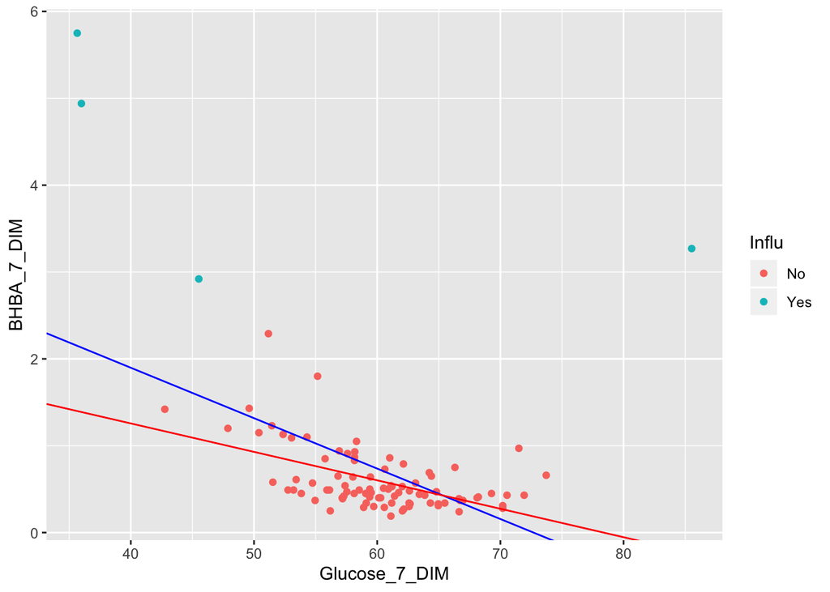

```r
# integrate removal information
Glucose_data_pred_rm_ck <- add_column(Glucose_data_pred,
                                      Influ = ifelse(rownames(Glucose_data_pred)%in%ck_index,"Yes","No"))
#
plot_simple_lm_rm_ck = ggplot(data = Glucose_data_pred_rm_ck,
                              aes(x = Glucose_7_DIM,y = BHBA_7_DIM,color = Influ)) +
  geom_point()+
  geom_abline(intercept=coef(lmod_glu)[1],
              slope=coef(lmod_glu)[2],color = "blue") + #model with Influential points
  geom_abline(intercept=coef(lmod_glu_rm_ck )[1],
              slope=coef(lmod_glu_rm_ck )[2],color = "red") #model without Influential points
plot_simple_lm_rm_ck
```

```r
##--------------------------------##
##  Time to play with the codes.  ##
##--------------------------------##
# Can you plot the new lines, without OUTLIER and High Leverage point, respectively???
```

Now we try some transformation.

```r
library(MASS)
lmod_glu <- lm(BHBA_7_DIM ~ Glucose_7_DIM,
                 data = Glucose_data)
# check data before run boxcox
summary(Glucose_data) # a. NO negative values b. max/min ratio is ratively high
```

```
##    BHBA_7_DIM     Glucose_7_DIM
##  Min.   :0.1900   Min.   :35.65
##  1st Qu.:0.3900   1st Qu.:56.19
##  Median :0.4900   Median :59.72
##  Mean   :0.7551   Mean   :59.68
##  3rd Qu.:0.7900   3rd Qu.:63.42
##  Max.   :5.7500   Max.   :85.53
```

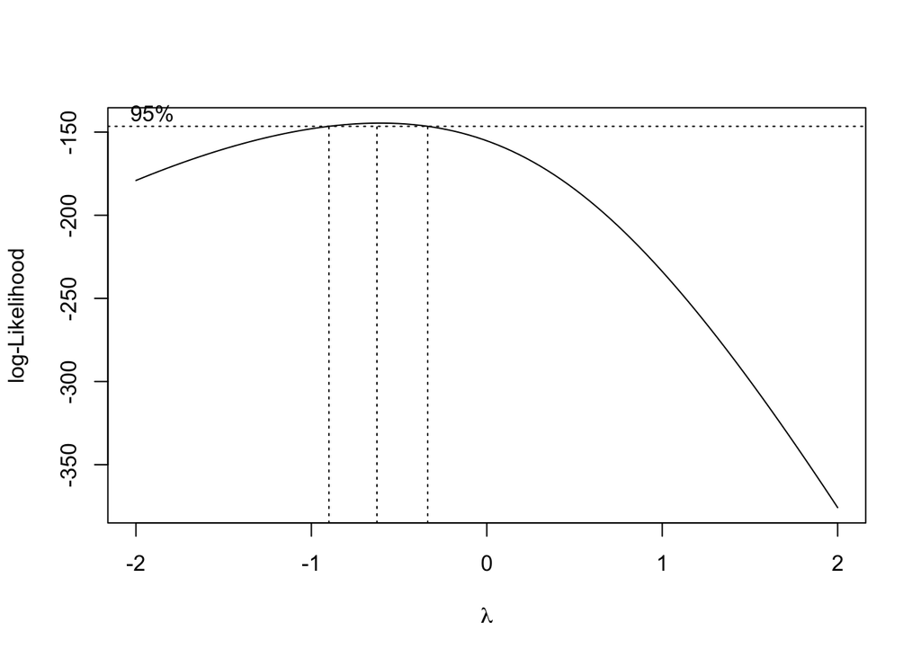

```r
boxcox(lmod_glu,plotit = T,lambda = seq(-2,2,by =0.2))
```

```r
# lambda = - 0.5
lmod_glu_bc_trans = lm(1/sqrt(BHBA_7_DIM) ~ Glucose_7_DIM,
                       data = Glucose_data)
summary(lmod_glu_bc_trans)
```

```
##
## Call:
## lm(formula = 1/sqrt(BHBA_7_DIM) ~ Glucose_7_DIM, data = Glucose_data)
##
## Residuals:
##      Min       1Q   Median       3Q      Max
## -1.43035 -0.24594  0.04102  0.20070  0.88162
##
## Coefficients:
##                Estimate Std. Error t value Pr(>|t|)
## (Intercept)   -0.015897   0.281837  -0.056    0.955
## Glucose_7_DIM  0.023375   0.004688   4.986 2.93e-06 ***
## ---
## Signif. codes:  0 '***' 0.001 '**' 0.01 '*' 0.05 '.' 0.1 ' ' 1
##
## Residual standard error: 0.3285 on 91 degrees of freedom
## Multiple R-squared:  0.2146, Adjusted R-squared:  0.206
## F-statistic: 24.86 on 1 and 91 DF,  p-value: 2.926e-06
```

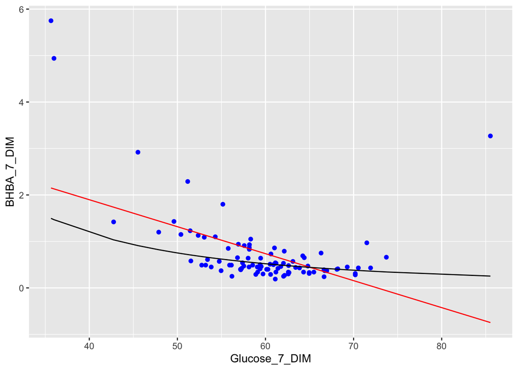

```r
# For visualization: transform back to original scale
# e.g. we predicted value is (1/sqrt(BHBA_7_DIM)) = 5
# then the actually value in original scale is BHBA_7_DIM = (1/5)^2
plot_simple_lm_bc_trans = ggplot(data = Glucose_data,aes(x = Glucose_7_DIM , y = BHBA_7_DIM)) +
  geom_point(color='blue')+
  geom_line(color='red',data = Glucose_data_pred ,aes(x = Glucose_7_DIM , y= my_prediction))+
  geom_line(aes(Glucose_data$Glucose_7_DIM,(1/predict(lmod_glu_bc_trans))^2))
plot_simple_lm_bc_trans
```

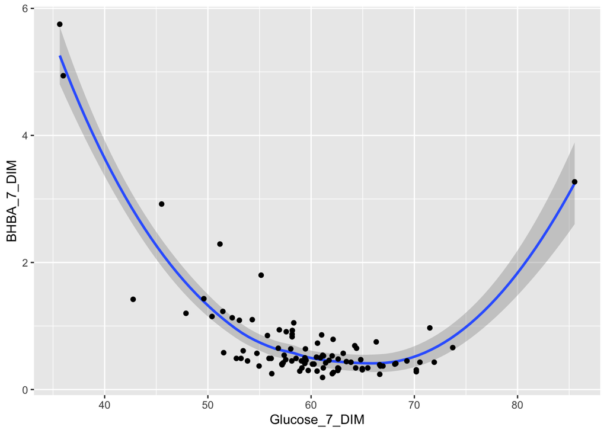

```r
##@
# ggplot can fit the line perfectly, but involves much complexity...
# Surely, it is good to know that but this may be too advanced...
library(ggplot2)
ggplot(Glucose_data, aes(Glucose_7_DIM,BHBA_7_DIM)) + geom_smooth() + geom_point()
```

```r
##--------------------------------##
##  Time to play with the codes.  ##
##--------------------------------##
# Can you try boxcox and back transfromation, WITHOUT the influential points?
# Remove the influential points we detected and then try to transform and trans back.
# Good luck.
```